# data-reanalysis-assignment

Sebastian

Tuesday, November 08, 2016

# Short description of the Study

Animals living with kin and nonkin should make social decisions based on the consequences for both direct and indirect fitness. Common vampire bats invest in stable cooperative relationships that benefit both components of inclusive fitness (kinship and reciprocal help). To disentangle these two factors, the authors conducted two types of playback trials using a group of captive vampire bats with mixed kinship and varying rates of dyadic food sharing histories. Individuals were presented with two speakers in maze trials. Speakers played contact calls from different familiar conspecifics. In experiment 1 (past donor trials), 15 bats had to choose between between calls recorded from either a frequent or rare food donor, but both “callers” were related to a similar degree with the subject. In experiment 2, 31 vampire bats had to choose between calls recorded from either a close or a distant relative, but both callers were matched for food-sharing history with the subject. The authors found that vampire bats were attracted to contact calls of frequent donors when controlling for kinship, but not to calls of kin when controlling for food sharing history. In addidion, respose and acoustic analysis suggest that bats recognized individuals from vocalizations. Together the results of the study corroborate prior observations in vampire bats that prior food sharing can overshadow relatedness in determining the social decisions of vampire bats.

## Short description of the statistical analysis in the article

1. To quantify food sharing history, the authors used a food sharing index from individual A to B. This food sharing index was calculated as the ln(x-1), where x is the food sharing rate from A to B. The raw data for these calculations was not available.
2. Calculation of relatedness: The authors genotyped 19 microsatellite markers and used Wang’s estimator in the R package “related”. The raw genotype dataset was not available.
3. Acoustic Analysis of Playback Stimuli: A Set of linear discriminant functions, permutation tests applied to linear models using the lmPerm package, and jackknifed linear discriminant function to determine if bats recognize individuals from vocalizations.
4. Playback response analysis: Statistical analysis of the experiment described below. The authors performed bootstrapping of response variables to determine 95% confidence intervals, permuted paired t-tests to determine statistically significant deviations from 0, and more conservative p-value estimations using Wilcoxon signed-rank tests for a subset of the data with lower sample size. I will try and repeat most of those analysis in this assignment.

## Short description of the Method (Playback experiment).

A subject bat was placed in a maze (see below) with five arms that allowed the subject to move forwards, backward, left, right or upwards. The bat was placed in the arm farthest from the camera, equidistant to the two speakers. After moving forward, it could enter the arms to the left or right, with each option leading towards a speaker simultaneously playing calls from either a control bat or a test bat. The bat could also move straight backwards or forwards away from either speaker, or climb upwards, which bats typically do as an escape response. Those options allowed to remove cases where bats where not motivated. Each trial lasted 10 minutes (600 seconds). If the bat didn’t make a choice in the first trial, the trial was discarded and a new trial began. Stimuli were presented on the left or right randomly. Maze was rotated 90 degree clockwise between each trial and the two trial types were presented on a random schedule to prevent order effects.

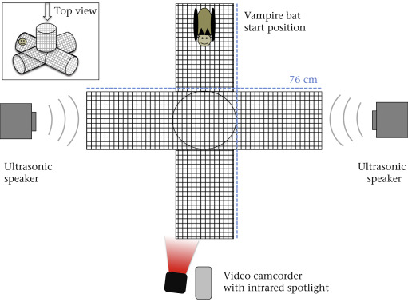

Figure 1: Playback maze

### Experiment 1 (Past donor)

Subject with a history of food sharing (N= 12 females, 3 males) was presented with choice between approaching contact calls from a frequent donor (test) and an infrequent donor or nondonor (control). Test and control bats differed in food donation rates but were matched by age and kinship.

### Experiment 2 (Kinship)

Subject (N = 12 females, 19 males) was presented with a choice between contact calls from a close relative (test) and a distant or non-relative (control). Test and control bats differed in their pairwise kinship with the subject, but they were closely matched wherever possible by age and past food sharing experience.

### Response variables for both experiments

Responses were measured by observers that were blind to the the playback treatments and design. The two response variables are differences between test and control (test-control).

1. Duration: Number of seconds that bats spend in either the control or the test arm. Response variable for analysis is therefore: Duration spend in test arm - duration spend in control arm. If positive, the bat spend more time in the test arm, if negative, the bat spend more time in the control arm.
2. Latency: The latency in seconds from the start of the trial until the bat first entered either the control or the test arm. If the bat never entered the arm, latency was scored 600 s (10 min trials). Response variable for analysis is therefore: Latency to enter test arm - latency to enter control arm.

I will start with uploading the dataset provided by the authors and by installing and opening the required packages…

```r
# required packages
#install.packages("ggplot2",repos="http://cran.us.r-project.org")
library(ggplot2)
# install.packages("curl",repos="http://cran.us.r-project.org")
library(curl)
#install.packages("boot",repos="http://cran.us.r-project.org")
library(boot)
#install.packages("plyr",repos="http://cran.us.r-project.or")
library(plyr)
#install.packages("broman",repos="http://cran.us.r-project.org")
library(broman)
# Upload the dataset
f<-curl("https://raw.githubusercontent.com/BastiStockmaier/data-reanalysis-assignment/master/playback_response_data.csv")
dataset<-read.csv(f,header=TRUE, sep=",")
```

The response variables (duration, latency) have long names in the original dataset, so I am going to change them using the “plyr” package.

```r
names(dataset)
```

```
##  [1] "subject.bat"                  "subject.sex"
##  [3] "trial.type"                   "test.bat"
##  [5] "control.bat"                  "test.relatedness"
##  [7] "control.relatedness"          "test.kinship"
##  [9] "control.kinship"              "subject.is.mother"
## [11] "dyad.is.mom.offspring"        "FSI.test"
## [13] "FSI.control"                  "test.arm"
## [15] "entered.test..control"        "test.control.time.in.arm..s."
```

```r
dataset<-rename(dataset,c("entered.test..control"="latency", "test.control.time.in.arm..s."="duration"))
head(dataset)
```

```
##   subject.bat subject.sex trial.type   test.bat control.bat
## 1       three      female      donor      cerce        mina
## 2        lucy      female      donor vampirella       cerce
## 3        mina      female      donor      bella        bat2
## 4        vlad        male      donor       lucy       bella
## 5    countess      female      donor   veronica        bat2
## 6         mya      female      donor      bella        lily
##   test.relatedness control.relatedness test.kinship control.kinship
## 1           0.1941             -0.3130       0.1941          0.0000
## 2           0.2195              0.1352       0.2195          0.1352
## 3          -0.2708             -0.6153       0.0000          0.0000
## 4          -0.0500             -0.1008       0.0000          0.0000
## 5           0.3005             -0.5607       0.3005          0.0000
## 6          -0.4202             -0.4619       0.0000          0.0000
##   subject.is.mother dyad.is.mom.offspring FSI.test FSI.control test.arm
## 1                 n                     n 4.795791    0.000000        r
## 2                 n                     n 4.521789    0.000000        l
## 3                 n                     n 4.287411    0.000000        r
## 4                 n                     n 2.479894    0.000000        l
## 5                 n                     n 6.237022    0.000000        r
## 6                 n                     n 5.848524    5.052257        l
##   latency duration
## 1      30       32
## 2    -600      131
## 3    -468       55
## 4       0        0
## 5      69       14
## 6    -207       46
```

Since there are two experiments (past donor and kin, explained above), I will also split the dataset accordingly..

```r
donors<-subset(dataset, trial.type=="donor")
head(donors)
```

```
##   subject.bat subject.sex trial.type   test.bat control.bat
## 1       three      female      donor      cerce        mina
## 2        lucy      female      donor vampirella       cerce
## 3        mina      female      donor      bella        bat2
## 4        vlad        male      donor       lucy       bella
## 5    countess      female      donor   veronica        bat2
## 6         mya      female      donor      bella        lily
##   test.relatedness control.relatedness test.kinship control.kinship
## 1           0.1941             -0.3130       0.1941          0.0000
## 2           0.2195              0.1352       0.2195          0.1352
## 3          -0.2708             -0.6153       0.0000          0.0000
## 4          -0.0500             -0.1008       0.0000          0.0000
## 5           0.3005             -0.5607       0.3005          0.0000
## 6          -0.4202             -0.4619       0.0000          0.0000
##   subject.is.mother dyad.is.mom.offspring FSI.test FSI.control test.arm
## 1                 n                     n 4.795791    0.000000        r
## 2                 n                     n 4.521789    0.000000        l
## 3                 n                     n 4.287411    0.000000        r
## 4                 n                     n 2.479894    0.000000        l
## 5                 n                     n 6.237022    0.000000        r
## 6                 n                     n 5.848524    5.052257        l
##   latency duration
## 1      30       32
## 2    -600      131
## 3    -468       55
## 4       0        0
## 5      69       14
## 6    -207       46
```

```r
kin<-subset(dataset,trial.type=="kin")
head(kin)
```

```
##    subject.bat subject.sex trial.type   test.bat control.bat
## 16     sheldon        male        kin vampirella       cerce
## 17       marce      female        kin      cerce        mina
## 18       bella      female        kin       lily        bat2
## 19       three      female        kin       bat2        lily
## 20    cerceson        male        kin      cerce        bat7
## 21     whimsey        male        kin vampirella        mina
##    test.relatedness control.relatedness test.kinship control.kinship
## 16           0.2704              0.1654       0.5000               0
## 17           0.3837              0.1529       0.5000               0
## 18           0.6920             -0.1634       0.5000               0
## 19           0.3636             -0.0648       0.3636               0
## 20           0.6293              0.1509       0.5000               0
## 21           0.2843             -0.1030       0.5000               0
##    subject.is.mother dyad.is.mom.offspring FSI.test FSI.control test.arm
## 16                 n                     y       NA          NA        l
## 17                 n                     y 5.707110           0        r
## 18                 y                     y 6.783608           0        l
## 19                 n                     n 0.000000           0        r
## 20                 n                     y 5.379897          NA        r
## 21                 n                     y 0.000000          NA        l
##    latency duration
## 16     -87       47
## 17      57      -48
## 18    -171      106
## 19     433      -36
## 20     213       16
## 21     -42      -36
```

The Authors present two plots showing individual differences in duration/latency for both the donor and the kin test. Which is what I will replicate next.

1. Differences in duration spend in test arm/control arm for both, donor and kinship test.

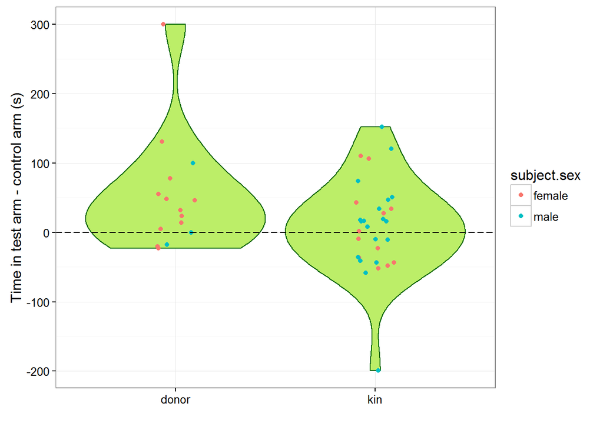

```r
p<-ggplot(dataset, aes(x=trial.type, y=duration))
p<-p+geom_violin(scale="width", adjust=1.5,trim="TRUE",color="darkgreen",fill="darkolivegreen2")
p<-p+geom_jitter(aes(color=subject.sex),width=0.25)
p<-p+geom_hline(yintercept=0, size=0.5,linetype=5)
p<-p+labs(y="Time in test arm - control arm (s)", x="")
p<-p+theme_bw()
p
```

(2) Differences in latency to enter test arm/control arm for both, donor and kinship test.

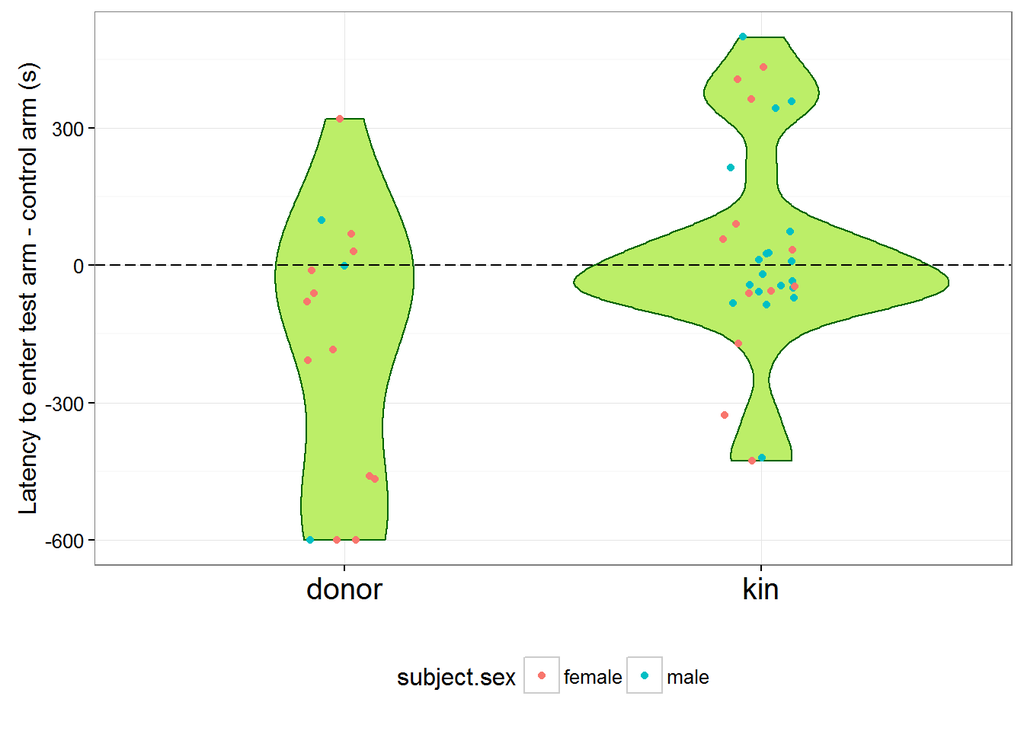

```r
p<-ggplot(dataset, aes(x=trial.type, y=latency))
p<-p+geom_violin(trim="TRUE",color="darkgreen",fill="darkolivegreen2")
p<-p+geom_jitter(aes(color=subject.sex),width=0.25)
p<-p+geom_hline(yintercept=0, size=0.5,linetype=5)
p<-p+labs(y="Latency to enter test arm - control arm (s)", x="")
p<-p+theme_bw()
p<-p+theme(legend.position="bottom",axis.text.x=element_text(size=15))
p
```

For comparison, I will attach the original figure to this file (HTML knit):

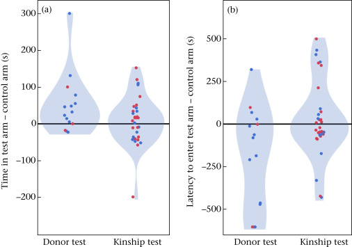

# Analysis

As mentioned above, I will focus on analyzing the response to the playback analysis. I will split up the analysis in the past donor experiment and the kin experiment.

## Past donor experiment analysis - duration

I want to start with some visual and descriptive analysis/statistics. When looking at the graph showing the duration each bat spend in the test vs control arm, it looks like the majority of bats lay in the positive upper half of the plot (above 0).

### Past donor experiment - duration, descriptive stats

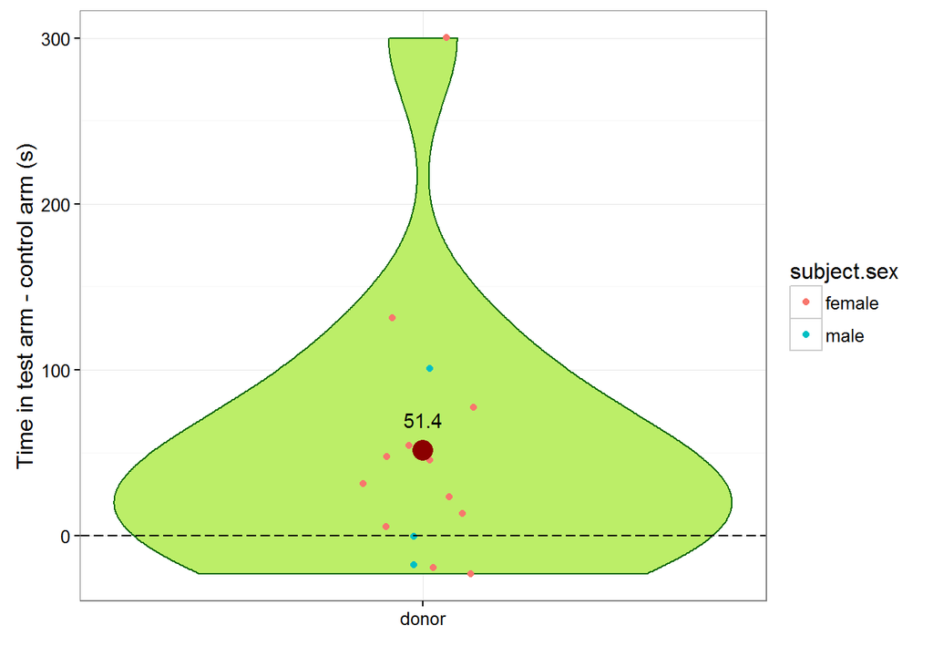

```r
mean.duration<-toString(mean(donors$duration))

p<-ggplot(donors, aes(x=trial.type, y=duration))
p<-p+geom_violin(scale="width", adjust=1.5,trim="TRUE",color="darkgreen",fill="darkolivegreen2")
p<-p+geom_jitter(aes(color=subject.sex),width=0.25)
p<-p+geom_hline(yintercept=0, size=0.5,linetype=5)
p<-p+labs(y="Time in test arm - control arm (s)", x="")
p<-p+theme_bw()
p<-p+stat_summary(fun.y=mean, color="darkred", geom="point", size=5)
p<-p+annotate("text", x=1, y=70, label=mean.duration)
p
```

It looks like bats spend more time in the test arm (past frequent food donor) compared to the control arm and are thus more attracted to contact calls from bats that donated blood in the past. The authors report that bats in this test spend on average 51 s longer in the test arm then in the control arm (see mean in plot).

### Past donor experiment - duration, bootstrapping and calculation of 95% CIs

The Authors state that the response data was non-normal, which is why they used a bootstrapping approach. A bootstapping approach does not asume an underlying distribution. In the following I will: (1) show the distribution of the response data in a histogram (2) write a function for a mean calculation used by the “boot” package to bootstrap the durations 5000 times (this function will be used later for the other analysis as well). (3) Calculate the confidence intervals of the boostrapping result using the package “boot”.

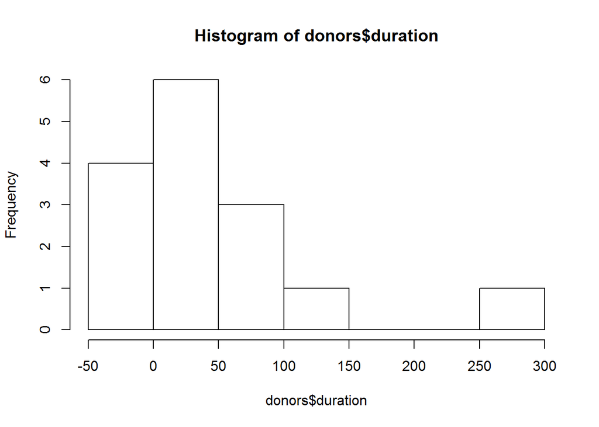

```r
hist(donors$duration) # distribution of response data
```

```r
my.mean<-function(x,i){ # function to calculate means repeatedly
  return(mean(x[i]))
}
donor.durations<-donors$duration # create a vector with the data to be bootstrapped
donor.durations
```

```
##  [1]  32 131  55   0  14  46  23  48 100  78 -23 -18 -20 300   5
```

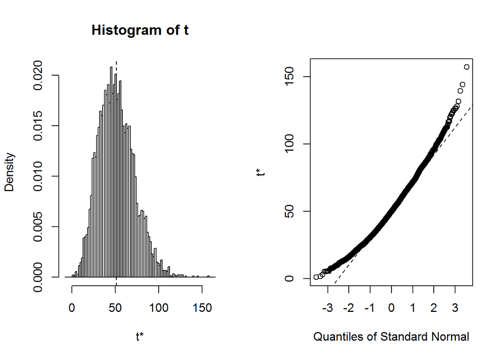

```r
donor.duration.boot<-boot(donor.durations, my.mean, 5000) # bootstrapping of the vector to calculate 5000 sample means
plot(donor.duration.boot)
```

```r
ci<-boot.ci(donor.duration.boot) # calculate 95 % CI
ci
```

```
## BOOTSTRAP CONFIDENCE INTERVAL CALCULATIONS
## Based on 5000 bootstrap replicates
##
## CALL :
## boot.ci(boot.out = donor.duration.boot)
##
## Intervals :
## Level      Normal              Basic
## 95%   (11.33, 91.36 )   ( 7.54, 86.06 )
##
## Level     Percentile            BCa
## 95%   ( 16.74,  95.26 )   ( 22.53, 110.84 )
## Calculations and Intervals on Original Scale
```

The authors show a 95% CI for this mean in their paper (12-91s). This comes close to our calculation using the default option for calculating CI’s in the package “boot”. For this “boot” uses a normal approximation. Since bootstrapping is a random process, these results will slightly change every time the function is executed.

### Past donor experiment - duration, calculation of one-sided p-value

Given the results provided (permutation:p), it seems like the authors calculate their one-sided p-values using a paired t-test (differences test-control) via 5000 permutations. This can be done using the “broman” package.

```r
p<-paired.perm.test(donor.durations, n.perm=5000)
p
```

```
## [1] 0.0074
```

Note again that this p-value most likely won’t resemble the one presented in the paper (0.0014). This is due to the random process of permutation. I was therefore interested what would happen if I’d repeat this test over and over again, and create a long vector of p-values (e.g for 100 times, otherwise it would take forever and freeze your computer).

```r
p.values<-NULL
for(i in 1:100){
p.values[i]<-paired.perm.test(donor.durations,n.perm=5000)
}
p.values
```

```
##   [1] 0.0070 0.0094 0.0076 0.0076 0.0084 0.0076 0.0064 0.0052 0.0082 0.0076
##  [11] 0.0070 0.0092 0.0074 0.0062 0.0070 0.0064 0.0066 0.0064 0.0106 0.0076
##  [21] 0.0072 0.0054 0.0072 0.0066 0.0076 0.0078 0.0088 0.0078 0.0050 0.0092
##  [31] 0.0084 0.0076 0.0092 0.0068 0.0068 0.0084 0.0070 0.0078 0.0066 0.0066
##  [41] 0.0082 0.0064 0.0060 0.0082 0.0078 0.0066 0.0072 0.0064 0.0068 0.0074
##  [51] 0.0072 0.0086 0.0088 0.0072 0.0044 0.0072 0.0060 0.0072 0.0076 0.0074
##  [61] 0.0080 0.0072 0.0088 0.0052 0.0094 0.0080 0.0084 0.0114 0.0072 0.0098
##  [71] 0.0084 0.0070 0.0066 0.0062 0.0096 0.0086 0.0086 0.0064 0.0060 0.0080
##  [81] 0.0074 0.0068 0.0096 0.0072 0.0094 0.0082 0.0070 0.0080 0.0074 0.0086
##  [91] 0.0066 0.0076 0.0068 0.0070 0.0074 0.0074 0.0082 0.0072 0.0078 0.0080
```

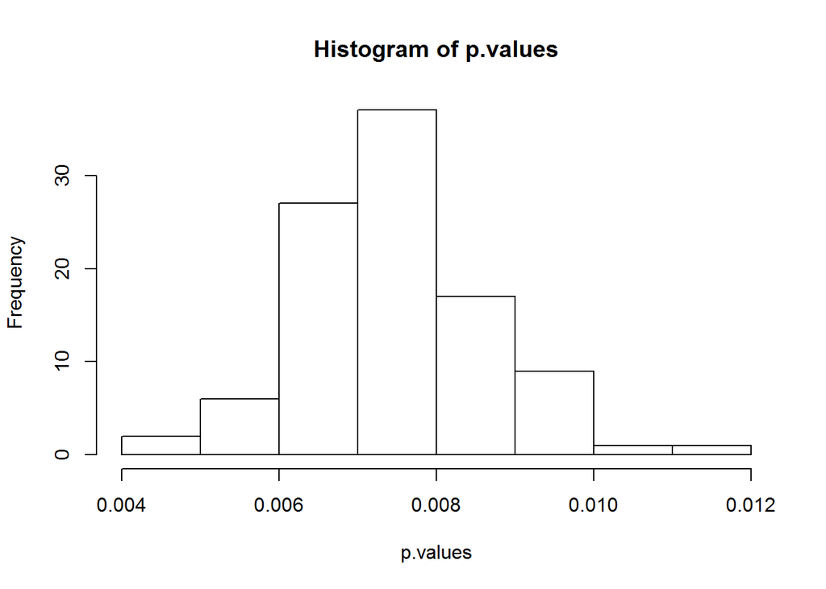

```r
hist(p.values, cex=0.4)
```

```r
summary(p.values>0.05) # Are there values above alpha = 0.05?
```

```
##    Mode   FALSE    NA's
## logical     100       0
```

```r
# Calculate some basic statistics from this distribution
m<-round(mean(p.values),digits=4)
s<-round(sd(p.values),digits=4)
n<-length(p.values)
v<-round(var(p.values), digits=6)
e<-round(sqrt(v/n), digits=6)
upper<-round((m + qnorm(0.975, mean = 0, sd = 1) * e),digits=4)
lower<-round((m + qnorm(0.025, mean = 0, sd = 1) * e),digits=4)

Results<-cbind(m,s,n,v,e,upper,lower)
colnames(Results)<-c("mean", "s.deviation", "n", "variance", "s.error", "upper.Ci", "lower.Ci")
rownames(Results)<-c("statistic")
Results
```

```
##             mean s.deviation   n variance s.error upper.Ci lower.Ci
## statistic 0.0075      0.0012 100    1e-06   1e-04   0.0077   0.0073
```

100 times repetition of this permutated paired t-test shows that no p-value falls over the choosen alpha-value of 0.05. I also calculated descriptive statistics for the distribution and show them in “Results”. The distribution looks almost normal (repeating the loop more often would have improved this).

### Past donor experiment - duration, more conservative Wilcoxon signed-rank test

The authors state that resampling tests can be problematic when a sample is too small (<20, as in one of our cases), and therefore provide more conservative p-values using a non-parametric Wilcoxon signed-rank test. I will also repeat this analysis..

```r
pw<-wilcox.test(donor.durations, alternative="greater", mu=0, correct=TRUE)
pw
```

```
##
##  Wilcoxon signed rank test with continuity correction
##
## data:  donor.durations
## V = 92.5, p-value = 0.006564
## alternative hypothesis: true location is greater than 0
```

### Past donor experiment - duration, summary of the results

```r
Results.paper<-c(51, 15, 12,91,0.0014,0.005)
Results.analysis<-c(mean(donors$duration),length(donors$duration),ci$normal[2], ci$normal[3],p,pw$p.value)
Comparison<-rbind(Results.paper, Results.analysis)
colnames(Comparison)<-c("mean","N", "lower CI", "upper CI", "permuted.p", "Wilcox.p")
Comparison
```

```
##                  mean  N lower CI upper CI permuted.p    Wilcox.p
## Results.paper    51.0 15 12.00000  91.0000     0.0014 0.005000000
## Results.analysis 51.4 15 11.33191  91.3626     0.0074 0.006563925
```

Interpretation: Generally, it seems like the results are comparable to the ones reported in the article. The permuted p-value deviates because of the random nature of permutations created by the permutation t-test. I have run it repeatedly, and it is always highly significant showing that the mean of 51.4 seconds significantly deviates from 0, and that bats spend a significant proportion of their time in the test-arm. The p-value of my wilcox test also slightly deviates from the one reported in the paper but is still highly significant.

I will now repeat the same analysis for the (1) donor experiment - latency, (2) kinship experiment - duration, and (3) kinship experiment - latency. However I will provide less explanation since the workflow through these analysis is basically identical…

## (1) Past donor experiment analysis - latency.

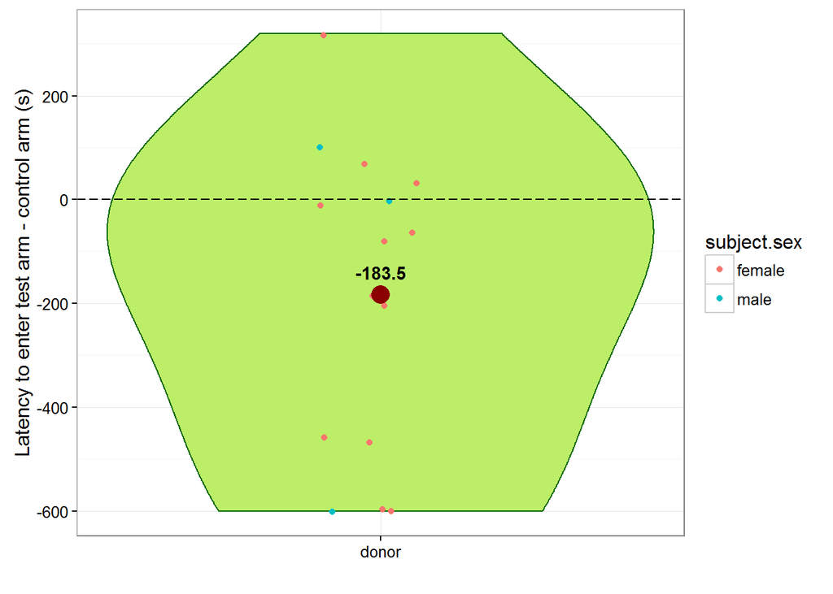

```r
mean.duration<-round(mean(donors$latency), digits=1)
mean.duration<-toString(mean.duration)

p<-ggplot(donors, aes(x=trial.type, y=latency))
p<-p+geom_violin(scale="width", adjust=1.5,trim="TRUE",color="darkgreen",fill="darkolivegreen2")
p<-p+geom_jitter(aes(color=subject.sex),width=0.25)
p<-p+geom_hline(yintercept=0, size=0.5,linetype=5)
p<-p+labs(y="Latency to enter test arm - control arm (s)", x="")
p<-p+theme_bw()
p<-p+stat_summary(fun.y=mean, color="darkred", geom="point", size=5)
p<-p+annotate("text", x=1, y=-140, label=mean.duration, fontface="bold")
p
```

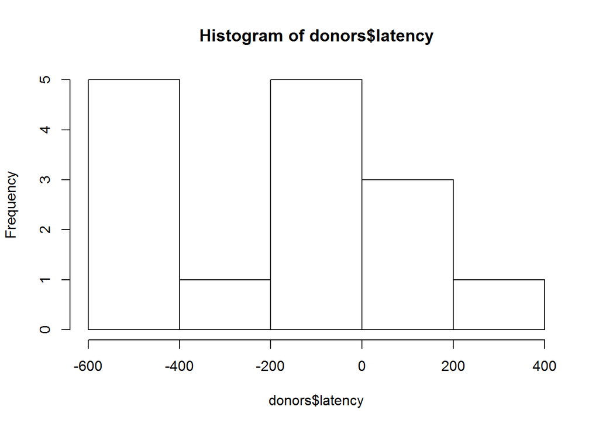

```r
hist(donors$latency)
```

```r
donor.latency<-donors$latency # create a vector with the data to be bootstrapped
donor.latency
```

```
##  [1]   30 -600 -468    0   69 -207  -11 -184 -600 -460  -79   98  320 -600
## [15]  -61
```

```r
donor.latency.boot<-boot(donor.latency, my.mean, 5000) # bootstrapping of the vector to calculate 5000 sample means
ci<-boot.ci(donor.latency.boot) # calculate 95 % CI
ci
```

```
## BOOTSTRAP CONFIDENCE INTERVAL CALCULATIONS
## Based on 5000 bootstrap replicates
##
## CALL :
## boot.ci(boot.out = donor.latency.boot)
##
## Intervals :
## Level      Normal              Basic
## 95%   (-326.8,  -40.7 )   (-323.7,  -38.0 )
##
## Level     Percentile            BCa
## 95%   (-329.1,  -43.4 )   (-334.4,  -49.2 )
## Calculations and Intervals on Original Scale
```

```r
p<-paired.perm.test(donor.latency, n.perm=5000) # permutation paired t-test
p
```

```
## [1] 0.0314
```

```r
pw<-wilcox.test(donor.latency, alternative="less", mu=0, correct=TRUE) # wilcoxon signed-rank test
pw
```

```
##
##  Wilcoxon signed rank test with continuity correction
##
## data:  donor.latency
## V = 21, p-value = 0.02571
## alternative hypothesis: true location is less than 0
```

```r
Results.paper<-c(-184, 15, -331, -42,0.0066,0.025)
Results.analysis<-c(mean(donors$latency),length(donors$latency),ci$normal[2], ci$normal[3],p,pw$p.value)
Comparison<-rbind(Results.paper, Results.analysis)
colnames(Comparison)<-c("mean","N", "lower CI", "upper CI", "permuted.p", "Wilcox.p")
Comparison
```

```
##                       mean  N  lower CI  upper CI permuted.p   Wilcox.p
## Results.paper    -184.0000 15 -331.0000 -42.00000     0.0066 0.02500000
## Results.analysis -183.5333 15 -326.8411 -40.67791     0.0314 0.02570801
```

Now let’s look at the kinship experiment….

## (2) Kinship experiment analysis - duration

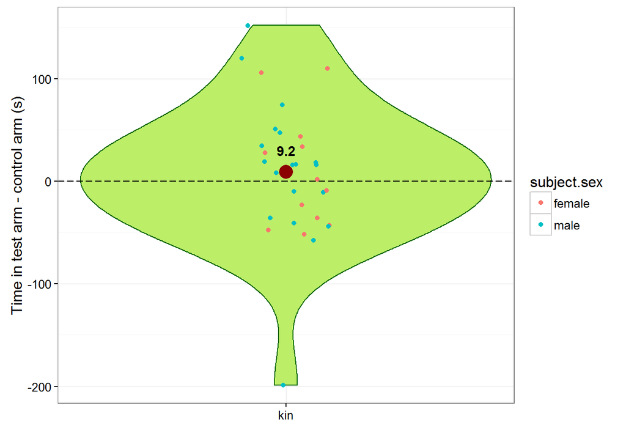

```r
mean.duration<-round(mean(kin$duration), digits=1)
mean.duration<-toString(mean.duration)

p<-ggplot(kin, aes(x=trial.type, y=duration))
p<-p+geom_violin(scale="width", adjust=1.5,trim="TRUE",color="darkgreen",fill="darkolivegreen2")
p<-p+geom_jitter(aes(color=subject.sex),width=0.25)
p<-p+geom_hline(yintercept=0, size=0.5,linetype=5)
p<-p+labs(y="Time in test arm - control arm (s)", x="")
p<-p+theme_bw()
p<-p+stat_summary(fun.y=mean, color="darkred", geom="point", size=5)
p<-p+annotate("text", x=1, y=30, label=mean.duration,fontface="bold")
p
```

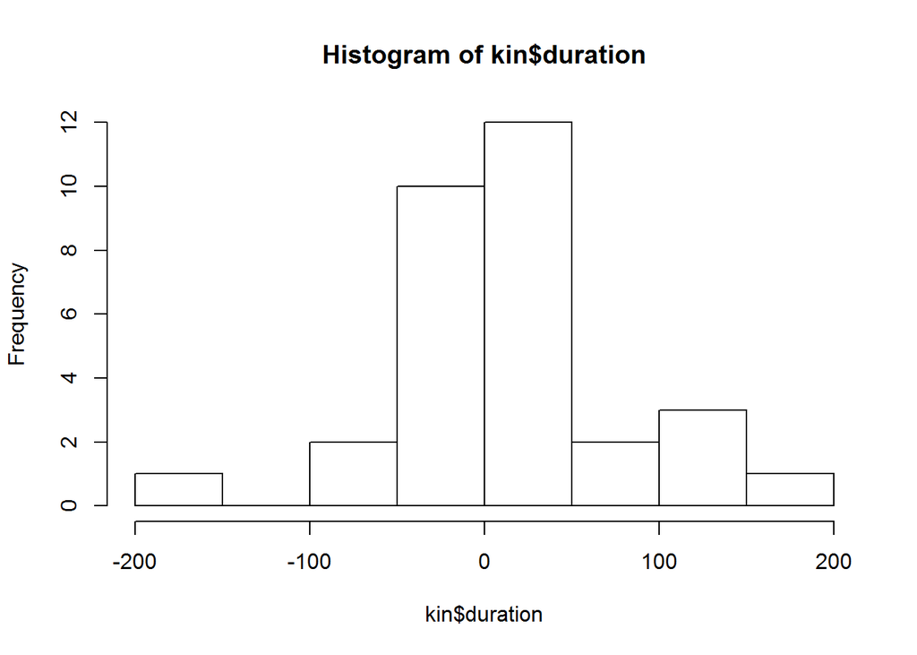

```r
hist(kin$duration)
```

```r
kin.duration<-kin$duration # create a vector with the data to be bootstrapped
kin.duration
```

```
##  [1]   47  -48  106  -36   16  -36  -11   28   16    8  152  -41   74  -58
## [15]  -10   34   16   51   18  120   19 -199    2   43  -52   34  110  -23
## [29]  -43  -44   -9
```

```r
kin.duration.boot<-boot(kin.duration, my.mean, 5000) # bootstrapping of the vector to calculate 5000 sample means
ci<-boot.ci(kin.duration.boot) # calculate 95 % CI
ci
```

```
## BOOTSTRAP CONFIDENCE INTERVAL CALCULATIONS
## Based on 5000 bootstrap replicates
##
## CALL :
## boot.ci(boot.out = kin.duration.boot)
##
## Intervals :
## Level      Normal              Basic
## 95%   (-13.657,  32.332 )   (-13.515,  32.709 )
##
## Level     Percentile            BCa
## 95%   (-14.386,  31.838 )   (-15.248,  31.555 )
## Calculations and Intervals on Original Scale
```

```r
p<-paired.perm.test(kin.duration, n.perm=5000) # permutation paired t-test
p
```

```
## [1] 0.4474
```

```r
Results.paper<-c(0,31,-13, 33,0.192)
Results.analysis<-c(mean(kin$duration),length(kin$duration),ci$normal[2], ci$normal[3],p)
Comparison<-rbind(Results.paper, Results.analysis)
colnames(Comparison)<-c("mean","N", "lower CI", "upper CI", "permuted.p")
Comparison
```

```
##                     mean  N  lower CI upper CI permuted.p
## Results.paper    0.00000 31 -13.00000 33.00000     0.1920
## Results.analysis 9.16129 31 -13.65744 32.33216     0.4474
```

Interpretation: This result shows that subjects in kinship trials did not significantly spend longer in the test arm with calls from kin, compared to the control arm with calls from nonkin (accept H0 that there is no difference between attraction to kin vs. nonkin calls). Both, the authors and I did not run a wilcox.test in this case since the sample size is >20.

## (3) Kinship experiment analysis - latency

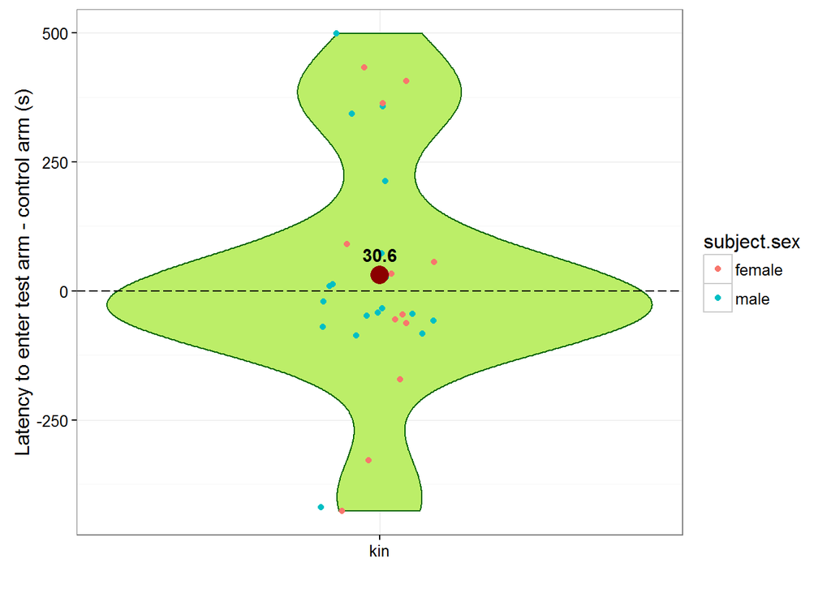

```r
mean.latency<-round(mean(kin$latency), digits=1)
mean.latency<-toString(mean.latency)

p<-ggplot(kin, aes(x=trial.type, y=latency))
p<-p+geom_violin(scale="width", adjust=1.5,trim="TRUE",color="darkgreen",fill="darkolivegreen2")
p<-p+geom_jitter(aes(color=subject.sex),width=0.25)
p<-p+geom_hline(yintercept=0, size=0.5,linetype=5)
p<-p+labs(y="Latency to enter test arm - control arm (s)", x="")
p<-p+theme_bw()
p<-p+stat_summary(fun.y=mean, color="darkred", geom="point", size=5)
p<-p+annotate("text", x=1, y=70, label=mean.latency,fontface="bold")
p
```

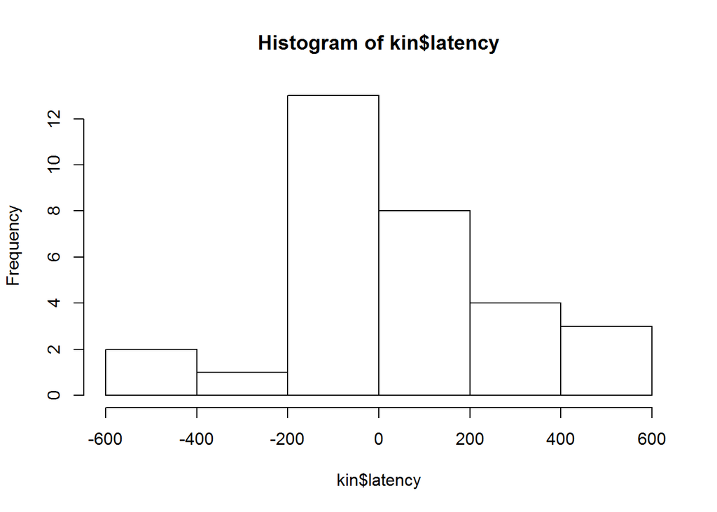

```r
hist(kin$latency)
```

```r
kin.latency<-kin$latency # create a vector with the data to be bootstrapped
kin.latency
```

```
##  [1]  -87   57 -171  433  213  -42    9 -328   13  -34   26  358  -58   73
## [15]   27  -83  -45  -20  -49 -420  -70  499   33  -62  -46   91 -427  364
## [29]  407  344  -56
```

```r
kin.latency.boot<-boot(kin.latency, my.mean, 5000) # bootstrapping of the vector to calculate 5000 sample means
ci<-boot.ci(kin.latency.boot) # calculate 95 % CI
ci
```

```
## BOOTSTRAP CONFIDENCE INTERVAL CALCULATIONS
## Based on 5000 bootstrap replicates
##
## CALL :
## boot.ci(boot.out = kin.latency.boot)
##
## Intervals :
## Level      Normal              Basic
## 95%   (-47.58, 109.06 )   (-48.42, 108.45 )
##
## Level     Percentile            BCa
## 95%   (-47.22, 109.64 )   (-45.65, 112.59 )
## Calculations and Intervals on Original Scale
```

```r
p<-paired.perm.test(kin.latency, n.perm=5000) # permutation paired t-test
p
```

```
## [1] 0.4574
```

```r
Results.paper<-c(0,31,-47, 114,1)
Results.analysis<-c(mean(kin$latency),length(kin$latency),ci$normal[2], ci$normal[3],p)
Comparison<-rbind(Results.paper, Results.analysis)
colnames(Comparison)<-c("mean","N", "lower CI", "upper CI", "permuted.p")
Comparison
```

```
##                     mean  N  lower CI upper CI permuted.p
## Results.paper     0.0000 31 -47.00000 114.0000     1.0000
## Results.analysis 30.6129 31 -47.58252 109.0611     0.4574
```

Interpretation: These results show that the subjects latency to enter either one of the test arms did not significantly differ (accept H0).

# Summary

Taken together these results indicate that Vampire bats are more attracted to contact calls of past donors than to contact calls of kin. The authors include a variety of controls into the analysis which are pretty much the same tests as shown above, but excluding different individuals from the analysis. E.g in one control they looked at attraction to the frequent donor after they excluded related individuals (nine trials). In all those controls the results remained unchanged and since the analysis is virually the same I will not repeat every control.